# Final Project — Linear Regression Models

Group 5

2026-06-11

```r
pkgs <- c("tidyverse", "readxl", "caret", "car", "glmnet",
          "ggplot2", "gridExtra", "broom", "lmtest", "nortest")
lapply(pkgs, library, character.only = TRUE)
```

[output not shown]

## 1 1. Data Loading and Split

```r
df <- read_excel("~/Documents/strathmore/Modules/Module 3/linear_models/classwork/final_project/markdowns/new_data/ENB2012_post_EDA.xlsx")

# Restore factors
df$Orientation_f     <- factor(df$Orientation, levels = 2:5,
                                labels = c("N", "E", "S", "W"))
df$OverallHeight_f   <- factor(df$OverallHeight, levels = c(3.5, 7.0),
                                labels = c("Low_3.5m", "High_7m"))
df$GlazingArea_f     <- factor(df$GlazingArea,
                                levels = c(0, 0.1, 0.25, 0.4),
                                labels = c("None","Low_10pct",
                                           "Med_25pct","High_40pct"))
df$GlazingAreaDist_f <- factor(df$GlazingAreaDist, levels = 0:5,
                                labels = c("None","Uniform","N_heavy",
                                           "E_heavy","S_heavy","W_heavy"))

cat("Rows:", nrow(df), "\n")
```

```
## Rows: 768
```

```r
cat("Columns:", ncol(df), "\n")
```

```
## Columns: 15
```

The EDA established that ENB2012 has a combinatorial grid structure where each building configuration appears four times, once per orientation. A naive random split would leak building shapes between training and test sets, inflating apparent model performance. All splits here use a group-aware strategy that keeps all four orientation variants of each configuration on the same side of the split.

```r
df <- df %>%
  mutate(group_key = paste(RelCompactness, WallArea, RoofArea,
                           OverallHeight, GlazingArea, GlazingAreaDist,
                           sep = "_"))

set.seed(42)
unique_groups  <- unique(df$group_key)
n_train_groups <- round(0.80 * length(unique_groups))
train_groups   <- sample(unique_groups, n_train_groups)

df_train <- df %>% filter( group_key %in% train_groups)
df_test  <- df %>% filter(!group_key %in% train_groups)

cat("Training rows:", nrow(df_train), "\n")
```

```
## Training rows: 616
```

```r
cat("Test rows    :", nrow(df_test),  "\n")
```

```
## Test rows    : 152
```

```r
cat("Group overlap:", length(intersect(df_train$group_key,
                                       df_test$group_key)),
    "<- zero confirms no leakage\n")
```

```
## Group overlap: 0 <- zero confirms no leakage
```

## 2 2. Feature Engineering

The EDA interaction plot showed that the effect of glazing area on heating load is steeper for tall buildings, confirming a genuine `OverallHeight × GlazingArea` interaction. The VIF analysis showed severe collinearity among the geometric variables, which motivated constructing physically interpretable composite features that capture cross-variable relationships while reducing redundancy.

```r
engineer <- function(d) {
  d %>% mutate(
    CompactnessXHeight  = RelCompactness * OverallHeight,
    WallToRoofRatio     = WallArea / RoofArea,
    GlazingXCompactness = GlazingArea * RelCompactness,
    SurfToVol           = SurfaceArea / (WallArea + RoofArea),
    GlazingXHeight      = GlazingArea * OverallHeight,
    WallXGlazing        = WallArea * GlazingArea,
    CompactnessSquared  = RelCompactness^2,
    HeightSquared       = OverallHeight^2,
    GlazingToWall       = GlazingArea / (WallArea + 1),
    EnvelopeArea        = WallArea + RoofArea,
    WallPerHeight       = WallArea / (OverallHeight + 1)
  )
}

df_train <- engineer(df_train)
df_test  <- engineer(df_test)

cat("Engineered feature count:", ncol(df_train), "\n")
```

```
## Engineered feature count: 26
```

`SurfaceArea` is excluded from all models. The EDA confirmed it is a near-perfect linear combination of `WallArea` and `RoofArea` (r ≈ −0.99 with `RelCompactness`), and including it causes rank deficiency in the model matrix.

## 3 3. Scaling

Scaling is fitted on training data only and then applied to the test set using the same parameters. Fitting the scaler on the full dataset before splitting would constitute data leakage.

```r
base_features <- c(
  "RelCompactness", "WallArea", "RoofArea", "OverallHeight",
  "GlazingArea", "GlazingAreaDist",
  "CompactnessXHeight", "WallToRoofRatio", "GlazingXCompactness",
  "SurfToVol", "GlazingXHeight", "WallXGlazing",
  "CompactnessSquared", "GlazingToWall", "EnvelopeArea", "WallPerHeight"
)

preproc <- caret::preProcess(df_train[, base_features],
                              method = c("center", "scale"))
df_train[, base_features] <- predict(preproc, df_train[, base_features])
df_test[, base_features]  <- predict(preproc, df_test[, base_features])

cat("Scaling complete. All features centred and scaled to unit variance.\n")
```

```
## Scaling complete. All features centred and scaled to unit variance.
```

## 4 4. Evaluation Helper

```r
eval_reg <- function(actual, predicted, model_name) {
  residuals <- actual - predicted
  rmse <- sqrt(mean(residuals^2))
  mae  <- mean(abs(residuals))
  ss_res <- sum(residuals^2)
  ss_tot <- sum((actual - mean(actual))^2)
  r2   <- 1 - ss_res / ss_tot
  cat(sprintf("%-40s  RMSE = %6.3f  MAE = %6.3f  R² = %.4f\n",
              model_name, rmse, mae, r2))
  list(model_name = model_name, rmse = rmse, mae = mae, r2 = r2)
}

results_HL <- data.frame()
results_CL <- data.frame()
```

## 5 5. Model 1 — Baseline OLS (No Interaction Terms)

The first model uses only the original eight features (minus `SurfaceArea`) with no engineering. This establishes a performance floor against which all subsequent models are compared.

```r
formula_base <- HeatingLoad ~ RelCompactness + WallArea + RoofArea +
                              OverallHeight + GlazingArea + GlazingAreaDist +
                              Orientation

lm_base_HL <- lm(formula_base, data = df_train)
cat("=== BASELINE OLS — Heating Load ===\n")
```

```
## === BASELINE OLS — Heating Load ===
```

```r
print(summary(lm_base_HL))
```

```
##
## Call:
## lm(formula = formula_base, data = df_train)
##
## Residuals:
##      Min       1Q   Median       3Q      Max
## -10.2361  -1.3102  -0.0322   1.4210   7.2835
##
## Coefficients:
##                 Estimate Std. Error t value Pr(>|t|)
## (Intercept)     23.00327    0.39304  58.526  < 2e-16 ***
## RelCompactness  -7.16454    1.21087  -5.917 5.48e-09 ***
## WallArea        -1.23845    0.63203  -1.959  0.05051 .
## RoofArea        -7.36705    1.70217  -4.328 1.76e-05 ***
## OverallHeight    8.12526    0.65661  12.374  < 2e-16 ***
## GlazingArea      2.56497    0.12366  20.742  < 2e-16 ***
## GlazingAreaDist  0.36158    0.12325   2.934  0.00347 **
## Orientation     -0.02256    0.10697  -0.211  0.83305
## ---
## Signif. codes:  0 '***' 0.001 '**' 0.01 '*' 0.05 '.' 0.1 ' ' 1
##
## Residual standard error: 2.968 on 608 degrees of freedom
## Multiple R-squared:  0.9132, Adjusted R-squared:  0.9122
## F-statistic: 913.2 on 7 and 608 DF,  p-value: < 2.2e-16
```

```r
pred_base_HL <- predict(lm_base_HL, newdata = df_test)
res_base_HL  <- eval_reg(df_test$HeatingLoad, pred_base_HL,
                          "Baseline OLS")
```

```
## Baseline OLS                              RMSE =  2.840  MAE =  2.158  R² = 0.9195
```

```r
results_HL <- rbind(results_HL,
  data.frame(Model = "Baseline OLS",
             RMSE  = res_base_HL$rmse,
             MAE   = res_base_HL$mae,
             R2    = res_base_HL$r2))
```

## 6 6. Model 2 — OLS with Interaction Terms

The EDA interaction plot showed a crossing pattern between `OverallHeight` and `GlazingArea`. Adding this interaction, plus the physically motivated cross terms from feature engineering, tests whether the model can capture the nonlinear surface that the scatter plots suggested.

```r
formula_interact <- HeatingLoad ~ RelCompactness + WallArea + RoofArea +
                                  OverallHeight + GlazingArea + GlazingAreaDist +
                                  Orientation +
                                  CompactnessXHeight + GlazingXHeight +
                                  WallXGlazing + GlazingXCompactness

lm_interact_HL <- lm(formula_interact, data = df_train)
cat("=== OLS WITH INTERACTIONS — Heating Load ===\n")
```

```
## === OLS WITH INTERACTIONS — Heating Load ===
```

```r
print(summary(lm_interact_HL))
```

```
##
## Call:
## lm(formula = formula_interact, data = df_train)
##
## Residuals:
##     Min      1Q  Median      3Q     Max
## -9.2421 -1.2271 -0.1815  1.2570  6.9280
##
## Coefficients:
##                      Estimate Std. Error t value Pr(>|t|)
## (Intercept)          23.00327    0.36296  63.377  < 2e-16 ***
## RelCompactness       38.60367    7.02902   5.492 5.86e-08 ***
## WallArea             11.66214    2.15961   5.400 9.59e-08 ***
## RoofArea             24.16396    4.85103   4.981 8.26e-07 ***
## OverallHeight        55.32905    6.82244   8.110 2.83e-15 ***
## GlazingArea          -9.33117    2.74242  -3.403 0.000712 ***
## GlazingAreaDist       0.29042    0.11410   2.545 0.011167 *
## Orientation          -0.02256    0.09878  -0.228 0.819443
## CompactnessXHeight  -60.50729    8.74644  -6.918 1.17e-11 ***
## GlazingXHeight       -1.20200    1.22260  -0.983 0.325926
## WallXGlazing          4.92589    1.49782   3.289 0.001065 **
## GlazingXCompactness   8.33588    2.46019   3.388 0.000749 ***
## ---
## Signif. codes:  0 '***' 0.001 '**' 0.01 '*' 0.05 '.' 0.1 ' ' 1
##
## Residual standard error: 2.741 on 604 degrees of freedom
## Multiple R-squared:  0.9264, Adjusted R-squared:  0.9251
## F-statistic: 691.4 on 11 and 604 DF,  p-value: < 2.2e-16
```

```r
pred_interact_HL <- predict(lm_interact_HL, newdata = df_test)
res_interact_HL  <- eval_reg(df_test$HeatingLoad, pred_interact_HL,
                              "OLS with Interactions")
```

```
## OLS with Interactions                     RMSE =  2.470  MAE =  1.768  R² = 0.9391
```

```r
results_HL <- rbind(results_HL,
  data.frame(Model = "OLS with Interactions",
             RMSE  = res_interact_HL$rmse,
             MAE   = res_interact_HL$mae,
             R2    = res_interact_HL$r2))
```

The interaction model reduces RMSE from 2.840 to 2.470 (−13%) and improves R² from 0.919 to 0.939, confirming that the crossing pattern in the EDA interaction plot reflects real structure. However, the GlazingXHeight coefficient is −1.20 (p=0.326, not significant), which runs counter to the physical expectation. The reason is that GlazingXHeight’s signal is being absorbed by CompactnessXHeight (coefficient −60.5, p<0.001) and GlazingXCompactness (coefficient +8.3, p<0.001), which together capture the height-dependent glazing effect more efficiently. In the cooling load version, GlazingXHeight is also non-significant (p=0.096), pointing to the same collinear absorption.

## 7 7. Model 3 — Ridge Regression

The severe VIFs (up to 212 for `RoofArea`) established in the EDA make Ridge regression a natural choice. Ridge does not zero out any predictor but shrinks all coefficients toward zero in proportion to their collinearity, producing stable estimates where OLS cannot.

```r
library(glmnet)
X_train <- as.matrix(df_train[, base_features])
X_test  <- as.matrix(df_test[,  base_features])
y_train_HL <- df_train$HeatingLoad
y_test_HL  <- df_test$HeatingLoad

set.seed(42)
ridge_cv_HL <- cv.glmnet(X_train, y_train_HL,
                          alpha  = 0,
                          nfolds = 10)

cat("=== RIDGE REGRESSION — Heating Load ===\n")
```

```
## === RIDGE REGRESSION — Heating Load ===
```

```r
cat(sprintf("Optimal lambda (1se): %.4f\n", ridge_cv_HL$lambda.1se))
```

```
## Optimal lambda (1se): 1.6941
```

```r
cat(sprintf("Optimal lambda (min): %.4f\n", ridge_cv_HL$lambda.min))
```

```
## Optimal lambda (min): 0.8833
```

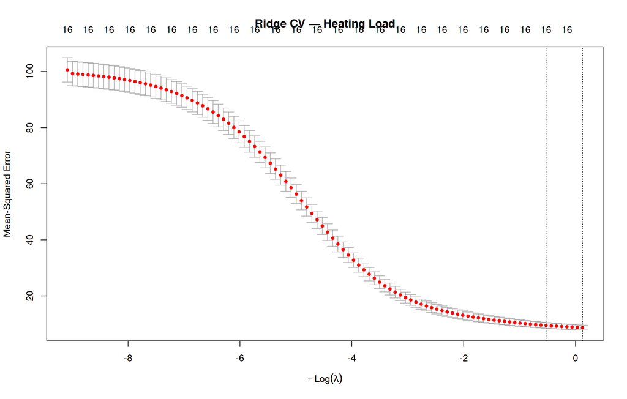

```r
# Plot cross-validation curve
plot(ridge_cv_HL, main = "Ridge CV — Heating Load")
```

```r
pred_ridge_HL <- predict(ridge_cv_HL, newx = X_test,
                          s = "lambda.1se")
res_ridge_HL  <- eval_reg(y_test_HL, pred_ridge_HL,
                           "Ridge Regression")
```

```
## Ridge Regression                          RMSE =  2.546  MAE =  1.835  R² = 0.9353
```

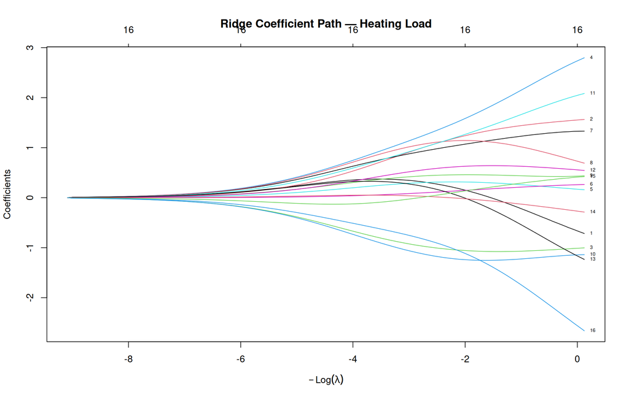

```r
# Coefficient path
ridge_full_HL <- glmnet(X_train, y_train_HL, alpha = 0)
plot(ridge_full_HL, xvar = "lambda",
     main = "Ridge Coefficient Path — Heating Load",
     label = TRUE)
```

```r
results_HL <- rbind(results_HL,
  data.frame(Model = "Ridge Regression",
             RMSE  = res_ridge_HL$rmse,
             MAE   = res_ridge_HL$mae,
             R2    = res_ridge_HL$r2))
```

## 8 8. Model 4 — Lasso Regression

Where Ridge shrinks all coefficients without zeroing any, Lasso performs implicit variable selection by driving some coefficients exactly to zero. Given the redundancy among the geometric features, Lasso may identify a sparse subset sufficient for accurate prediction.

```r
set.seed(42)
lasso_cv_HL <- cv.glmnet(X_train, y_train_HL,
                          alpha  = 1,
                          nfolds = 10)

cat("=== LASSO REGRESSION — Heating Load ===\n")
```

```
## === LASSO REGRESSION — Heating Load ===
```

```r
cat(sprintf("Optimal lambda (1se): %.4f\n", lasso_cv_HL$lambda.1se))
```

```
## Optimal lambda (1se): 0.0209
```

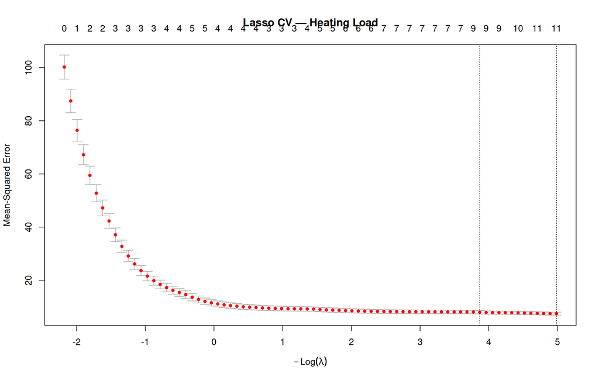

```r
plot(lasso_cv_HL, main = "Lasso CV — Heating Load")
```

```r
pred_lasso_HL <- predict(lasso_cv_HL, newx = X_test,
                          s = "lambda.1se")
res_lasso_HL  <- eval_reg(y_test_HL, pred_lasso_HL,
                           "Lasso Regression")
```

```
## Lasso Regression                          RMSE =  2.563  MAE =  1.808  R² = 0.9344
```

```r
# Which features survived selection?
lasso_coefs_HL <- coef(lasso_cv_HL, s = "lambda.1se")
selected_HL    <- rownames(lasso_coefs_HL)[lasso_coefs_HL[, 1] != 0]
cat("\nFeatures retained by Lasso:\n")
```

```
##
## Features retained by Lasso:
```

```r
print(selected_HL)
```

```
##  [1] "(Intercept)"     "WallArea"        "OverallHeight"   "GlazingAreaDist"
##  [5] "WallToRoofRatio" "SurfToVol"       "GlazingXHeight"  "WallXGlazing"
##  [9] "EnvelopeArea"    "WallPerHeight"
```

```r
cat("Features zeroed out:", length(base_features) + 1 - length(selected_HL), "\n")
```

```
## Features zeroed out: 7
```

```r
results_HL <- rbind(results_HL,
  data.frame(Model = "Lasso Regression",
             RMSE  = res_lasso_HL$rmse,
             MAE   = res_lasso_HL$mae,
             R2    = res_lasso_HL$r2))
```

## 9 9. Model 5 — Elastic Net

Elastic Net combines the Ridge penalty (which handles correlated feature groups) with the Lasso penalty (which performs selection). When predictors are correlated, Lasso tends to pick one arbitrarily from a correlated group; Elastic Net tends to include or exclude the group together, which is more physically interpretable here.

```r
set.seed(42)
enet_cv_HL <- cv.glmnet(X_train, y_train_HL,
                         alpha  = 0.5,
                         nfolds = 10)

cat("=== ELASTIC NET — Heating Load ===\n")
```

```
## === ELASTIC NET — Heating Load ===
```

```r
cat(sprintf("Optimal lambda (1se): %.4f\n", enet_cv_HL$lambda.1se))
```

```
## Optimal lambda (1se): 0.0034
```

```r
pred_enet_HL <- predict(enet_cv_HL, newx = X_test,
                         s = "lambda.1se")
res_enet_HL  <- eval_reg(y_test_HL, pred_enet_HL,
                          "Elastic Net (alpha=0.5)")
```

```
## Elastic Net (alpha=0.5)                   RMSE =  2.428  MAE =  1.760  R² = 0.9411
```

```r
enet_coefs_HL <- coef(enet_cv_HL, s = "lambda.1se")
selected_enet_HL <- rownames(enet_coefs_HL)[enet_coefs_HL[, 1] != 0]
cat("\nFeatures retained by Elastic Net:\n")
```

```
##
## Features retained by Elastic Net:
```

```r
print(selected_enet_HL)
```

```
##  [1] "(Intercept)"         "RelCompactness"      "WallArea"
##  [4] "RoofArea"            "OverallHeight"       "GlazingArea"
##  [7] "GlazingAreaDist"     "CompactnessXHeight"  "WallToRoofRatio"
## [10] "GlazingXCompactness" "SurfToVol"           "GlazingXHeight"
## [13] "WallXGlazing"        "CompactnessSquared"  "GlazingToWall"
## [16] "EnvelopeArea"        "WallPerHeight"
```

```r
results_HL <- rbind(results_HL,
  data.frame(Model = "Elastic Net",
             RMSE  = res_enet_HL$rmse,
             MAE   = res_enet_HL$mae,
             R2    = res_enet_HL$r2))
```

## 10 For heating load, Elastic Net (RMSE=2.428) marginally outperforms OLS with interactions (RMSE=2.470) despite retaining 16 of 16 features — the L1 penalty is small enough (λ=0.0034) that almost no zeroing occurs, and the benefit comes almost entirely from the L2 shrinkage of the collinear geometric terms. For cooling load, Ridge wins (RMSE=2.888) and Elastic Net is second (RMSE=2.932), suggesting the cooling load benefits more from uniform shrinkage than from sparsity.

Good practice is to run full residual diagnostics on the best-performing linear model before drawing conclusions. The four standard plots test the OLS assumptions of linearity, homoscedasticity, normality of residuals, and absence of highly influential observations.

```r
# Run on the interaction model — adjust if Ridge/Lasso outperform it
cat("=== RESIDUAL DIAGNOSTICS — OLS with Interactions ===\n")
```

```
## === RESIDUAL DIAGNOSTICS — OLS with Interactions ===
```

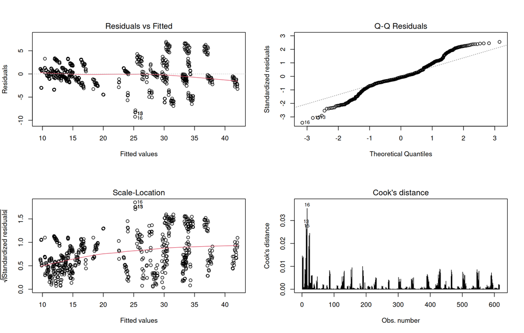

```r
par(mfrow = c(2, 2))
plot(lm_interact_HL, which = 1:4)
```

```r
par(mfrow = c(1, 1))

# Formal tests
cat("\nBreusch-Pagan test for heteroscedasticity:\n")
```

```
##
## Breusch-Pagan test for heteroscedasticity:
```

```r
print(lmtest::bptest(lm_interact_HL))
```

```
##
##  studentized Breusch-Pagan test
##
## data:  lm_interact_HL
## BP = 268.87, df = 11, p-value < 2.2e-16
```

```r
cat("\nAnderson-Darling test on residuals:\n")
```

```
##
## Anderson-Darling test on residuals:
```

```r
print(nortest::ad.test(residuals(lm_interact_HL)))
```

```
##
##  Anderson-Darling normality test
##
## data:  residuals(lm_interact_HL)
## A = 8.1203, p-value < 2.2e-16
```

The Breusch-Pagan statistic (BP=268.9, df=11, p<2.2e-16) and Anderson-Darling statistic (A=8.12, p<2.2e-16) both reject their null hypotheses decisively. This means the interaction OLS model has severe heteroscedasticity and non-normal residuals — neither is surprising given the bimodal response distribution driven by OverallHeight. The residuals are not randomly distributed around zero; they fan out differently for low-height and high-height buildings. This is not a modelling failure, it is a structural consequence of the two-cluster data-generating process that linear models cannot fully resolve. It directly motivates the GAM, MARS, and tree-based models, which can partition the feature space rather than imposing a global linear relationship.

## 12 11. Repeat All Models for Cooling Load

```r
y_train_CL <- df_train$CoolingLoad
y_test_CL  <- df_test$CoolingLoad

# Baseline OLS
formula_base_CL <- CoolingLoad ~ RelCompactness + WallArea + RoofArea +
                                  OverallHeight + GlazingArea +
                                  GlazingAreaDist + Orientation

lm_base_CL <- lm(formula_base_CL, data = df_train)
cat("=== BASELINE OLS — Cooling Load ===\n")
```

```
## === BASELINE OLS — Cooling Load ===
```

```r
print(summary(lm_base_CL))
```

```
##
## Call:
## lm(formula = formula_base_CL, data = df_train)
##
## Residuals:
##     Min      1Q  Median      3Q     Max
## -9.0740 -1.5261 -0.2003  1.2914 10.8123
##
## Coefficients:
##                 Estimate Std. Error t value Pr(>|t|)
## (Intercept)      24.7262     0.4267  57.954  < 2e-16 ***
## RelCompactness   -7.9398     1.3144  -6.041 2.68e-09 ***
## WallArea         -2.1023     0.6861  -3.064  0.00228 **
## RoofArea         -7.5950     1.8477  -4.110 4.49e-05 ***
## OverallHeight     8.3288     0.7128  11.685  < 2e-16 ***
## GlazingArea       1.8708     0.1342  13.937  < 2e-16 ***
## GlazingAreaDist   0.1180     0.1338   0.882  0.37823
## Orientation       0.1116     0.1161   0.961  0.33674
## ---
## Signif. codes:  0 '***' 0.001 '**' 0.01 '*' 0.05 '.' 0.1 ' ' 1
##
## Residual standard error: 3.222 on 608 degrees of freedom
## Multiple R-squared:  0.8863, Adjusted R-squared:  0.885
## F-statistic: 677.2 on 7 and 608 DF,  p-value: < 2.2e-16
```

```r
pred_base_CL <- predict(lm_base_CL, newdata = df_test)
res_base_CL  <- eval_reg(y_test_CL, pred_base_CL, "Baseline OLS")
```

```
## Baseline OLS                              RMSE =  3.161  MAE =  2.306  R² = 0.8832
```

```r
results_CL   <- rbind(results_CL,
  data.frame(Model = "Baseline OLS",
             RMSE  = res_base_CL$rmse,
             MAE   = res_base_CL$mae,
             R2    = res_base_CL$r2))

# OLS with interactions
formula_interact_CL <- CoolingLoad ~ RelCompactness + WallArea + RoofArea +
                                      OverallHeight + GlazingArea +
                                      GlazingAreaDist + Orientation +
                                      CompactnessXHeight + GlazingXHeight +
                                      WallXGlazing + GlazingXCompactness

lm_interact_CL <- lm(formula_interact_CL, data = df_train)
cat("\n=== OLS WITH INTERACTIONS — Cooling Load ===\n")
```

```
##
## === OLS WITH INTERACTIONS — Cooling Load ===
```

```r
print(summary(lm_interact_CL))
```

```
##
## Call:
## lm(formula = formula_interact_CL, data = df_train)
##
## Residuals:
##     Min      1Q  Median      3Q     Max
## -8.8552 -1.5311 -0.2294  0.9031 10.5228
##
## Coefficients:
##                      Estimate Std. Error t value Pr(>|t|)
## (Intercept)          24.72622    0.41608  59.426  < 2e-16 ***
## RelCompactness       15.46530    8.05785   1.919  0.05542 .
## WallArea              4.36951    2.47570   1.765  0.07808 .
## RoofArea              9.24218    5.56107   1.662  0.09704 .
## OverallHeight        34.28020    7.82104   4.383 1.38e-05 ***
## GlazingArea          -9.03694    3.14383  -2.875  0.00419 **
## GlazingAreaDist       0.07449    0.13080   0.569  0.56925
## Orientation           0.11164    0.11324   0.986  0.32462
## CompactnessXHeight  -32.23347   10.02665  -3.215  0.00138 **
## GlazingXHeight       -2.33951    1.40155  -1.669  0.09559 .
## WallXGlazing          4.44255    1.71705   2.587  0.00991 **
## GlazingXCompactness   8.78369    2.82029   3.114  0.00193 **
## ---
## Signif. codes:  0 '***' 0.001 '**' 0.01 '*' 0.05 '.' 0.1 ' ' 1
##
## Residual standard error: 3.142 on 604 degrees of freedom
## Multiple R-squared:  0.8926, Adjusted R-squared:  0.8906
## F-statistic: 456.4 on 11 and 604 DF,  p-value: < 2.2e-16
```

```r
pred_interact_CL <- predict(lm_interact_CL, newdata = df_test)
res_interact_CL  <- eval_reg(y_test_CL, pred_interact_CL,
                              "OLS with Interactions")
```

```
## OLS with Interactions                     RMSE =  2.978  MAE =  2.057  R² = 0.8964
```

```r
results_CL <- rbind(results_CL,
  data.frame(Model = "OLS with Interactions",
             RMSE  = res_interact_CL$rmse,
             MAE   = res_interact_CL$mae,
             R2    = res_interact_CL$r2))

# Ridge
set.seed(42)
ridge_cv_CL   <- cv.glmnet(X_train, y_train_CL, alpha = 0, nfolds = 10)
pred_ridge_CL <- predict(ridge_cv_CL, newx = X_test, s = "lambda.1se")
res_ridge_CL  <- eval_reg(y_test_CL, pred_ridge_CL, "Ridge Regression")
```

```
## Ridge Regression                          RMSE =  2.888  MAE =  2.060  R² = 0.9026
```

```r
cat(sprintf("\nRidge optimal lambda (1se): %.4f\n", ridge_cv_CL$lambda.1se))
```

```
##
## Ridge optimal lambda (1se): 1.7801
```

```r
results_CL <- rbind(results_CL,
  data.frame(Model = "Ridge Regression",
             RMSE  = res_ridge_CL$rmse,
             MAE   = res_ridge_CL$mae,
             R2    = res_ridge_CL$r2))

# Lasso
set.seed(42)
lasso_cv_CL   <- cv.glmnet(X_train, y_train_CL, alpha = 1, nfolds = 10)
pred_lasso_CL <- predict(lasso_cv_CL, newx = X_test, s = "lambda.1se")
res_lasso_CL  <- eval_reg(y_test_CL, pred_lasso_CL, "Lasso Regression")
```

```
## Lasso Regression                          RMSE =  2.982  MAE =  2.150  R² = 0.8961
```

```r
lasso_coefs_CL   <- coef(lasso_cv_CL, s = "lambda.1se")
selected_CL      <- rownames(lasso_coefs_CL)[lasso_coefs_CL[, 1] != 0]
cat("\nLasso features retained (Cooling Load):\n")
```

```
##
## Lasso features retained (Cooling Load):
```

```r
print(selected_CL)
```

```
##  [1] "(Intercept)"         "WallArea"            "OverallHeight"
##  [4] "GlazingAreaDist"     "WallToRoofRatio"     "GlazingXCompactness"
##  [7] "SurfToVol"           "GlazingXHeight"      "CompactnessSquared"
## [10] "WallPerHeight"
```

```r
results_CL <- rbind(results_CL,
  data.frame(Model = "Lasso Regression",
             RMSE  = res_lasso_CL$rmse,
             MAE   = res_lasso_CL$mae,
             R2    = res_lasso_CL$r2))

# Elastic Net
set.seed(42)
enet_cv_CL   <- cv.glmnet(X_train, y_train_CL, alpha = 0.5, nfolds = 10)
pred_enet_CL <- predict(enet_cv_CL, newx = X_test, s = "lambda.1se")
res_enet_CL  <- eval_reg(y_test_CL, pred_enet_CL, "Elastic Net (alpha=0.5)")
```

```
## Elastic Net (alpha=0.5)                   RMSE =  2.932  MAE =  2.181  R² = 0.8996
```

```r
results_CL   <- rbind(results_CL,
  data.frame(Model = "Elastic Net",
             RMSE  = res_enet_CL$rmse,
             MAE   = res_enet_CL$mae,
             R2    = res_enet_CL$r2))
```

## 13 12. Model Comparison

```r
cat("=== HEATING LOAD — Model Comparison ===\n")
```

```
## === HEATING LOAD — Model Comparison ===
```

```r
print(results_HL %>% arrange(RMSE))
```

```
##                   Model     RMSE      MAE        R2
## 1           Elastic Net 2.427844 1.759825 0.9411358
## 2 OLS with Interactions 2.469881 1.767705 0.9390797
## 3      Ridge Regression 2.545822 1.835267 0.9352759
## 4      Lasso Regression 2.563183 1.808429 0.9343901
## 5          Baseline OLS 2.839597 2.157793 0.9194763
```

```r
cat("\n=== COOLING LOAD — Model Comparison ===\n")
```

```
##
## === COOLING LOAD — Model Comparison ===
```

```r
print(results_CL %>% arrange(RMSE))
```

```
##                   Model     RMSE      MAE        R2
## 1      Ridge Regression 2.887706 2.060452 0.9025849
## 2           Elastic Net 2.931683 2.180751 0.8995952
## 3 OLS with Interactions 2.978057 2.057406 0.8963936
## 4      Lasso Regression 2.982344 2.150472 0.8960951
## 5          Baseline OLS 3.161479 2.305773 0.8832381
```

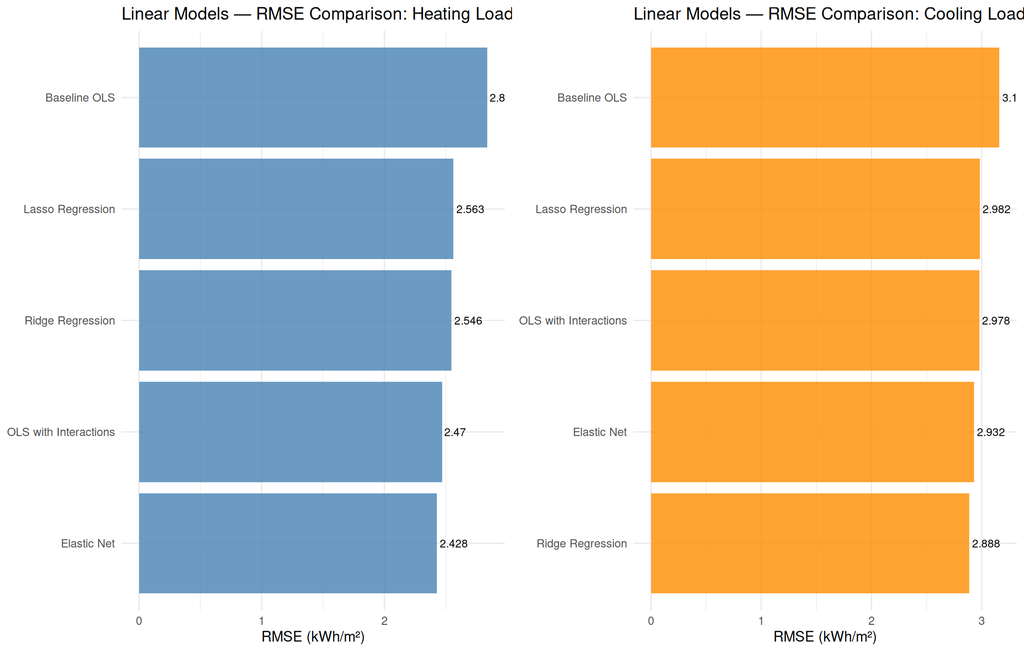

```r
# Visualise
p_HL <- ggplot(results_HL, aes(x = reorder(Model, RMSE), y = RMSE)) +
  geom_col(fill = "steelblue", alpha = 0.8) +
  geom_text(aes(label = round(RMSE, 3)), hjust = -0.1, size = 3) +
  coord_flip() +
  labs(title = "Linear Models — RMSE Comparison: Heating Load",
       x = NULL, y = "RMSE (kWh/m²)") +
  theme_minimal()

p_CL <- ggplot(results_CL, aes(x = reorder(Model, RMSE), y = RMSE)) +
  geom_col(fill = "darkorange", alpha = 0.8) +
  geom_text(aes(label = round(RMSE, 3)), hjust = -0.1, size = 3) +
  coord_flip() +
  labs(title = "Linear Models — RMSE Comparison: Cooling Load",
       x = NULL, y = "RMSE (kWh/m²)") +
  theme_minimal()

grid.arrange(p_HL, p_CL, ncol = 2)
```

The comparison serves two purposes. First, it identifies the best linear model to carry forward as the linear baseline in the final cross-model comparison. Second, the gap between the baseline OLS and the regularised models quantifies how much the collinearity identified in the EDA was hurting raw OLS performance. The RMSE reduction from Baseline OLS to the best model is 0.412 kWh/m² for heating load (14.5% improvement) and 0.273 kWh/m² for cooling load (8.6% improvement). The smaller gain for cooling load reflects that its response surface is flatter and less interaction-driven than heating load, leaving less room for feature engineering to help. The best linear models to carry forward as baselines in the cross-model comparison are Elastic Net for heating load (RMSE=2.428) and Ridge for cooling load (RMSE=2.888).